# Investigation of the distribution of means of 40 exponential distributed random variables and comparing it with the CLT

Olga Larina

5/17/2019

## Overview

In this project (Statistical Inference Course Project, Part 1) I will investigate the distribution of averages of 40 exponential distributed random variables in R and compare it with the Central Limit Theorem. I’m going to simulate 1000 variables, count their mean and variance and compare it to the theoretical mean and variance. I’m going also to compare the distribution of random exponentials with the distribution of averages of 40 exponentials.

## Simulations

First, let’s simulate 1000 exponential distributed random variables and 1000 means of 40 exponential distributed random variables. I set:

- lambda = 0.2 for all of the simulations, according to the task.
- arbitrary seed to get the same results every time I generate it.

```r
n <- 1000
lambda <- 0.2
set.seed(25534)
variables <- rexp(n, lambda)
mns = NULL
for (i in 1 : 1000) mns = c(mns, mean(rexp(40,lambda)))
```

Now I want to take a look on simulated averages.

```r
summary(mns)
```

```
##    Min. 1st Qu.  Median    Mean 3rd Qu.    Max.
##   2.827   4.466   4.935   4.993   5.502   7.679
```

### Sample Mean versus Theoretical Mean

Now, let’s talk about the mean of the averages (sample mean):

```r
mns_sample_mean <- mean(mns)
round(mns_sample_mean,3)
```

```
## [1] 4.993
```

The theoretical mean, according to CLT, is the population mean, for the exponential distribution it is 1/lambda. Let’s count it and plot theoretical and sample mean.

```r
mns_theoretical_mean <- 1/lambda
mns_theoretical_mean
```

```
## [1] 5
```

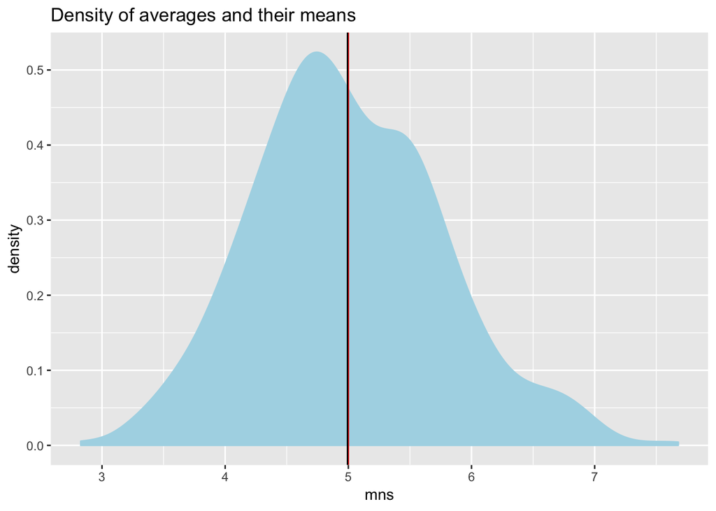

```r
library(ggplot2)
g <- ggplot(data.frame(mns = mns), aes(x = mns))
g <- g + geom_density(col = "lightblue", fill = "lightblue")
gMean <- g + labs(title="Density of averages and their means")
gMean <- gMean + geom_vline(xintercept = mns_theoretical_mean, col = "red")
gMean <- gMean + geom_vline(xintercept = mns_sample_mean, col = "black")
gMean
```

So, means are pretty close, CLT works. The black line is the sample mean and the red one is the theoretical mean.

### Sample Variance versus Theoretical Variance

I’ll talk about standard deviation (standard deviation = sqrt(variance)) because it has the same units as variables. Simulated averages have standard deviation:

```r
mns_sample_sd <- sd(mns)
round(mns_sample_sd,3)
```

```
## [1] 0.775
```

The standard deviation of distribution of averages (theoretical standard deviation) equals to standard error of the means of exponential variables:

```r
mns_theoretical_sd <- 1/lambda/sqrt(40)
round(mns_theoretical_sd,3)
```

```
## [1] 0.791
```

So, theoretical (according to CLT) and sample sd are close also.

### Distribution

Now, let’s compare the distribution of averages of 40 exponential random variables and the distribution of exponential random variables.

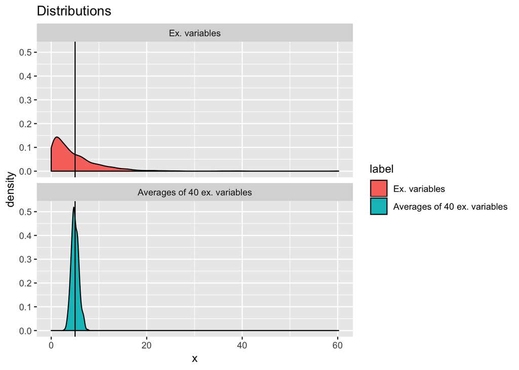

```r
data1 <- data.frame(x = variables, label = rep("Ex. variables",n))
data2 <- data.frame(x = mns, label = rep("Averages of 40 ex. variables",n))
data <- rbind(data1,data2)

gg <- ggplot(data, aes(x = x))
gg <- gg + geom_density(aes(fill=label)) + facet_wrap(.~label, nrow=2)
gg <- gg + labs(title="Distributions")
gg <- gg + geom_vline(xintercept = mns_theoretical_mean, col = "black")
gg
```

The distribution of averages looks more Gaussian (normal) than the distribution of exponential variables. The distribution of averages is centered at the population mean - it is 5 (black line) and the distribution is almost symmetrical about the center. It is also more concentrated about the center than the distribution of exponential variables.

## Conclusions

We simulated 1000 averages of 40 exponential distributed random variables and counted the mean and the sd (variance) of the data. Then, we assumed that 40 variables are enough to use CLT and counted theoretical mean and sd using CLT. Means and sds are very close to each other which improves the power of CLT.

We also looked at the distribution of averages - and it is almost normal, just like CLT claims. One can see also that it is more concentrated about the center than the distribution of exponential variables.

## Appendix

We know theoretical sd and mean, so we can calculate 95% confidence intervals for the mean of averages. I will use CLT because I have 40 points and it seems to be enough.

```r
round(mns_theoretical_mean + c(-1,1)*qnorm(0.975)*mns_theoretical_sd,3)
```

```
## [1] 3.451 6.549
```

It contains our sample mean 4.993 as expected.

Let’s also plot our density and density of the normal distributions with the theoretical sd and mean to compare it.

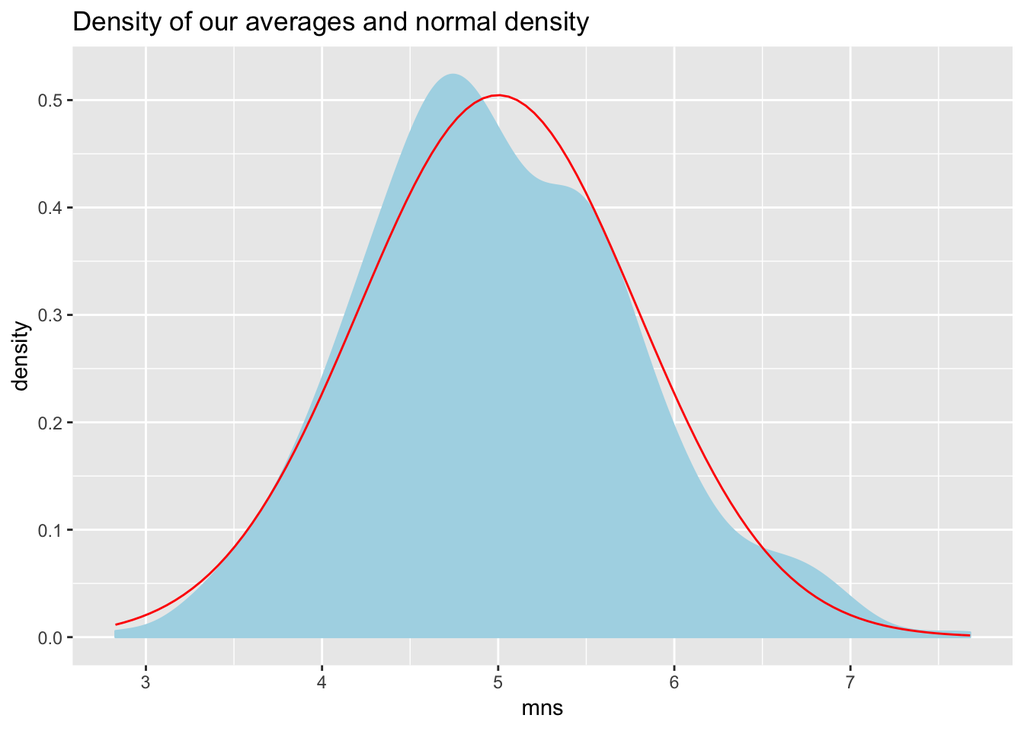

```r
gd <- g + labs(title="Density of our averages and normal density")
gd <- gd + stat_function(fun = dnorm, geom = "line", args = list(mean=mns_theoretical_mean,
                                                                 sd = mns_theoretical_sd),col="red")
gd
```

So, distribution of averages is really close to normal.